# Homework Problem 2

Natalie Robinson

September 26, 2017

# Homework Problem

```r
library(curl)
f <- f <- curl("https://raw.githubusercontent.com/fuzzyatelin/fuzzyatelin.github.io/master/AN597_Fall17/zombies.csv")
d <- read.csv(f, header = TRUE, sep = ",", stringsAsFactors = FALSE)
head(d)
```

```
##   id first_name last_name gender   height   weight zombies_killed
## 1  1      Sarah    Little Female 62.88951 132.0872              2
## 2  2       Mark    Duncan   Male 67.80277 146.3753              5
## 3  3    Brandon     Perez   Male 72.12908 152.9370              1
## 4  4      Roger   Coleman   Male 66.78484 129.7418              5
## 5  5      Tammy    Powell Female 64.71832 132.4265              4
## 6  6    Anthony     Green   Male 71.24326 152.5246              1
##   years_of_education                           major      age
## 1                  1                medicine/nursing 17.64275
## 2                  3 criminal justice administration 22.58951
## 3                  1                       education 21.91276
## 4                  6                  energy studies 18.19058
## 5                  3                       logistics 21.10399
## 6                  4                  energy studies 21.48355
```

1. Calculate the population mean and standard deviation for each quantitative random variable (height, weight, age, number of zombies killed, and years of education). NOTE: You will not want to use the built in var() and sd() commands as these are for samples.

```r
# get population mean how we did in module 8
k <- length(d$height) #this is 1000
n <- 5 #randomly choose samples of 5
m_height <- NULL #dummy variable to hold each sample
for (i in 1:k){
  m_height[[i]] <- sample(d$height, size=n, replace=FALSE)
}
head(m_height)
```

```
## [[1]]
## [1] 70.99726 61.98588 60.95832 65.07953 66.48566
##
## [[2]]
## [1] 65.07139 65.27007 63.76315 75.30248 69.49730
##
## [[3]]
## [1] 71.02192 72.58839 77.36758 63.25111 75.45580
##
## [[4]]
## [1] 61.95252 65.37115 66.50468 69.38269 76.59291
##
## [[5]]
## [1] 74.47735 73.60768 62.93356 69.54820 72.41608
##
## [[6]]
## [1] 63.52487 76.07529 70.25889 71.02901 65.27007
```

```r
# calculate a mean height
mu_height <- NULL
for (i in 1:k){
  mu_height[i] <- mean(m_height[[i]])
}
mean(mu_height)
```

```
## [1] 67.62466
```

```r
# do the same thing (with different variable/assigned names) for the other variables

k <- length(d$weight) #this is 1000
n <- 5 #randomly choose samples of 5
m_weight <- NULL #dummy variable to hold each sample
for (i in 1:k){
  m_weight[[i]] <- sample(d$weight, size=n, replace=FALSE)
}
head(m_weight)
```

```
## [[1]]
## [1] 101.4664 156.9905 163.6238 137.5064 118.0478
##
## [[2]]
## [1] 167.3627 141.4530 140.0505 145.2425 153.4659
##
## [[3]]
## [1] 157.0922 135.6414 130.1309 158.1921 144.9394
##
## [[4]]
## [1] 171.2448 125.8349 148.8549 167.3073 167.1740
##
## [[5]]
## [1] 160.3177 141.2748 128.2554 149.9674 100.6353
##
## [[6]]
## [1] 149.9921 133.4684 148.5103 137.1078 163.0445
```

```r
mu_weight <- NULL
for (i in 1:k){
  mu_weight[i] <- mean(m_weight[[i]])
}
mean(mu_weight)
```

```
## [1] 143.9426
```

```r
k <- length(d$age) #this is 1000
n <- 5 #randomly choose samples of 5
m_age <- NULL #dummy variable to hold each sample
for (i in 1:k){
  m_age[[i]] <- sample(d$age, size=n, replace=FALSE)
}
head(m_age)
```

```
## [[1]]
## [1] 21.32136 25.17245 16.40678 23.76093 19.73432
##
## [[2]]
## [1] 20.53096 25.23058 21.85695 23.76093 17.95568
##
## [[3]]
## [1] 19.08275 22.34703 25.32669 19.19078 27.55264
##
## [[4]]
## [1] 24.85453 21.93743 18.94045 20.39527 17.88162
##
## [[5]]
## [1] 23.15592 20.93828 20.40242 24.03706 18.39359
##
## [[6]]
## [1] 16.78669 15.76811 21.54377 17.07809 23.82158
```

```r
mu_age <- NULL
for (i in 1:k){
  mu_age[i] <- mean(m_age[[i]])
}
mean(mu_age)
```

```
## [1] 20.07988
```

```r
k <- length(d$zombies_killed) #this is 1000
n <- 5 #randomly choose samples of 5
m_zombies_killed <- NULL #dummy variable to hold each sample
for (i in 1:k){
  m_zombies_killed[[i]] <- sample(d$zombies_killed, size=n, replace=FALSE)
}
head(m_zombies_killed)
```

```
## [[1]]
## [1] 3 2 4 3 2
##
## [[2]]
## [1] 3 0 4 5 3
##
## [[3]]
## [1] 2 0 2 0 2
##
## [[4]]
## [1] 3 5 0 4 5
##
## [[5]]
## [1] 5 2 4 3 2
##
## [[6]]
## [1] 3 2 5 6 5
```

```r
mu_zombies_killed <- NULL
for (i in 1:k){
  mu_zombies_killed[i] <- mean(m_zombies_killed[[i]])
}
mean(mu_zombies_killed)
```

```
## [1] 2.999
```

```r
k <- length(d$years_of_education) #this is 1000
n <- 5 #randomly choose samples of 5
m_years_of_education <- NULL #dummy variable to hold each sample
for (i in 1:k){
  m_years_of_education[[i]] <- sample(d$years_of_education, size=n, replace=FALSE)
}
head(m_years_of_education)
```

```
## [[1]]
## [1] 4 3 7 5 1
##
## [[2]]
## [1] 4 2 6 3 5
##
## [[3]]
## [1] 1 4 0 3 5
##
## [[4]]
## [1] 2 2 3 5 1
##
## [[5]]
## [1] 2 3 1 1 5
##
## [[6]]
## [1] 2 4 2 3 1
```

```r
mu_years_of_education <- NULL
for (i in 1:k){
  mu_years_of_education[i] <- mean(m_years_of_education[[i]])
}
mean(mu_years_of_education)
```

```
## [1] 3.026
```

2. Use {ggplot} and make boxplots of each of these variables by gender

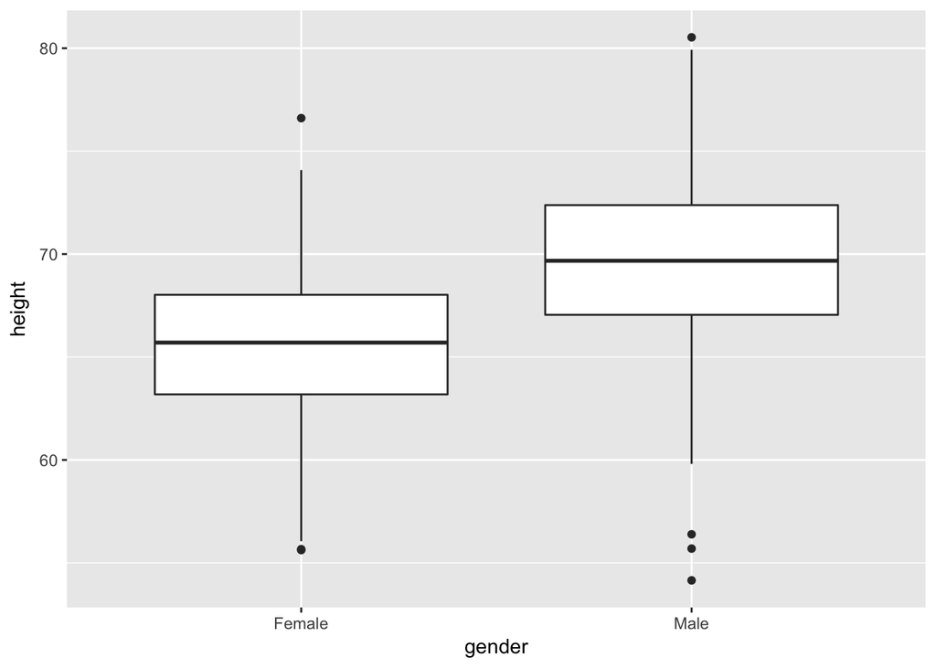

```r
library(ggplot2)
p <- ggplot(data = d, aes(x = gender, y = height))
p <- p + geom_boxplot()
p
```

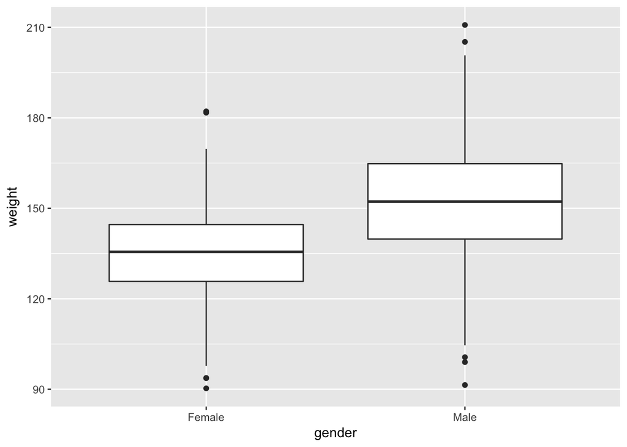

```r
library(ggplot2)
p <- ggplot(data = d, aes(x = gender, y = weight))
p <- p + geom_boxplot()
p
```

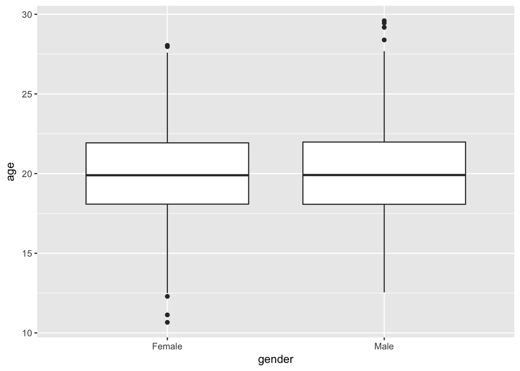

```r
library(ggplot2)
p <- ggplot(data = d, aes(x = gender, y = age))
p <- p + geom_boxplot()
p
```

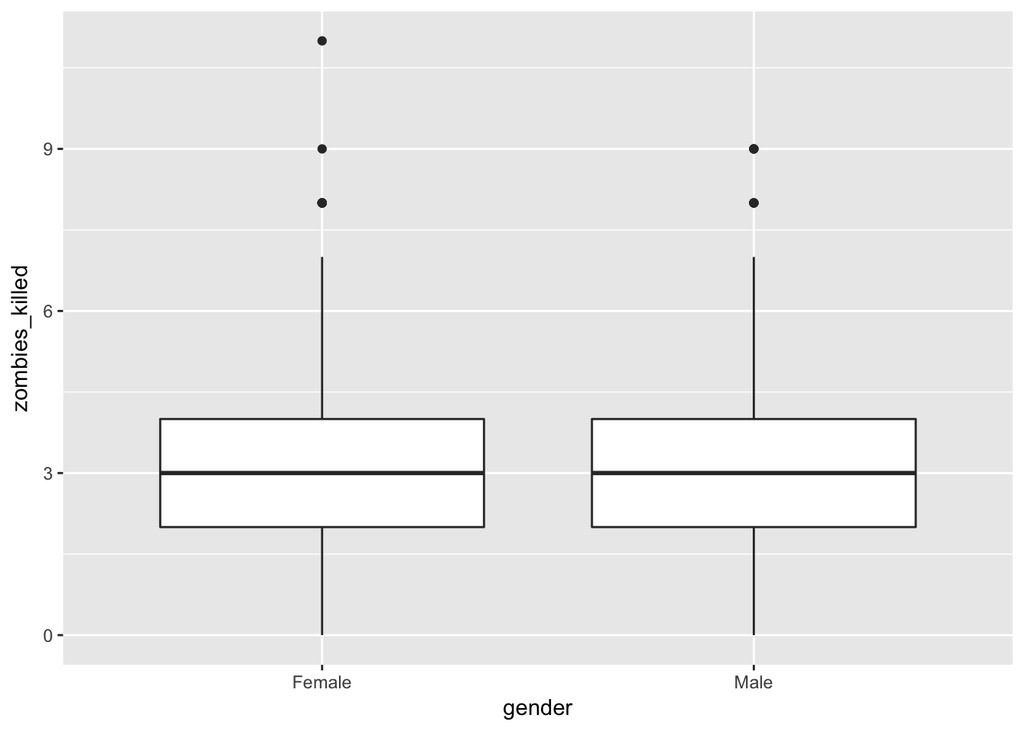

```r
library(ggplot2)
p <- ggplot(data = d, aes(x = gender, y = zombies_killed))
p <- p + geom_boxplot()
p
```

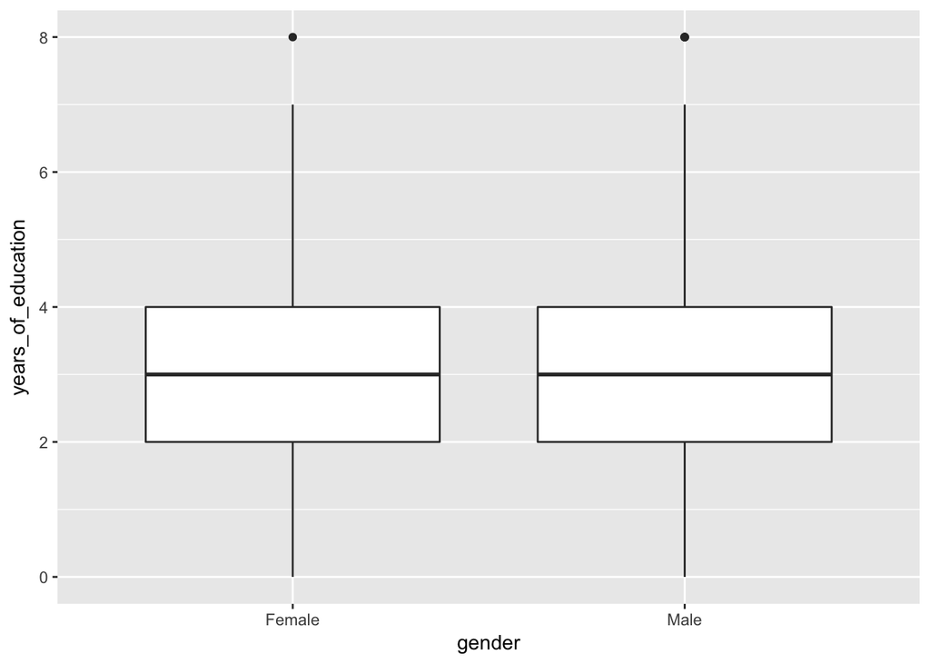

```r
library(ggplot2)
p <- ggplot(data = d, aes(x = gender, y = years_of_education))
p <- p + geom_boxplot()
p
```

3. Use {ggplot} and make scatterplots of height and weight in relation to age. Do these variables seem to be related? In what way?

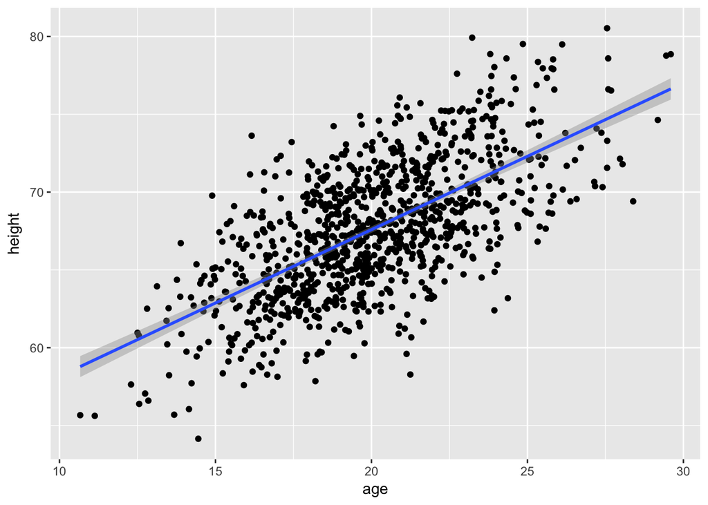

```r
p <- ggplot(data = d, aes(x = age, y = height))
p <- p + geom_point()
age_height <- p + geom_smooth(method = "lm")
age_height
```

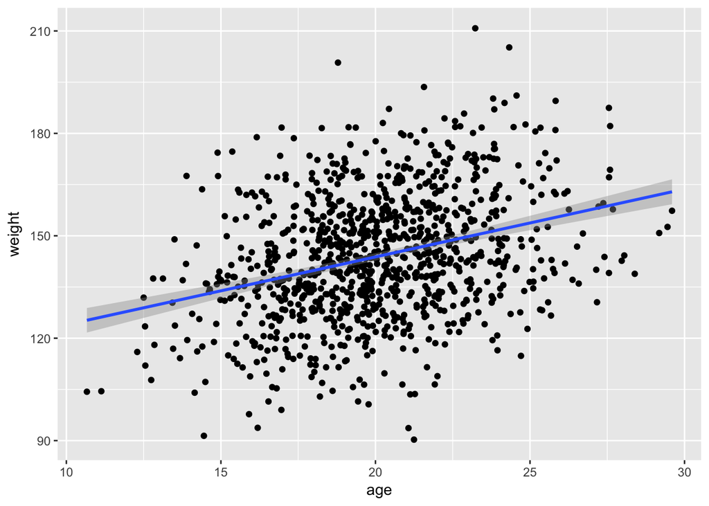

```r
p <- ggplot(data = d, aes(x = age, y = weight))
p <- p + geom_point()
age_weight <- p + geom_smooth(method = "lm")
age_weight
```

Both height and weight are positively correlated with age. As age increases, so does height/weight. The slope of the regression line for weight is not quite as steep as it is for height. Logically, this makes sense. As you grow older, your body grows in both height and weight.

4. Using histograms and Q-Q plots, check whether the quantitative variables seem to be drawn from a normal distribution. Which seem to be and which do not (hint: not all are drawn from the normal distribution)? For those that are not, can you determine what common distribution they are drawn from?

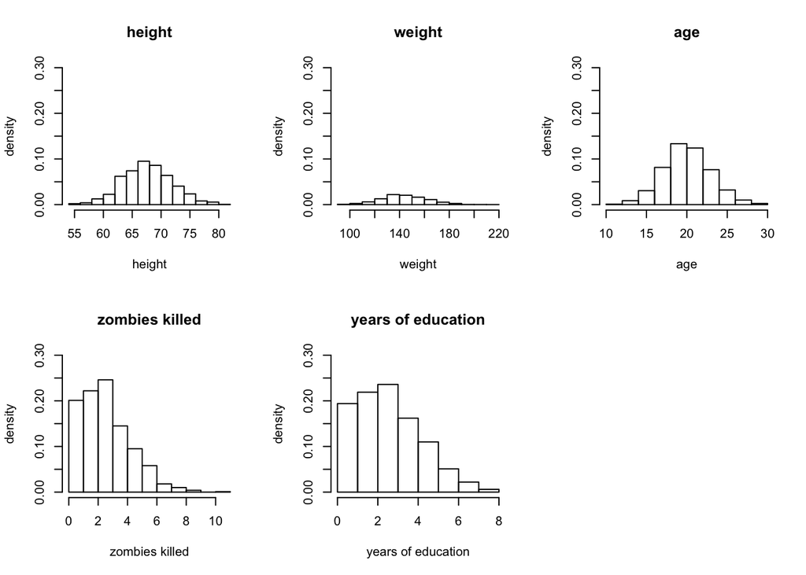

```r
par(mfrow = c(2, 3))  # gives 3 panels in 2 rows to see them all together
attach(d)
hist(height, freq = FALSE, main = "height", xlab = "height",
    ylab = "density", ylim = c(0, 0.3))
hist(weight, freq = FALSE, main = "weight", xlab = "weight",
    ylab = "density", ylim = c(0, 0.3))
hist(age, freq = FALSE, main = "age", xlab = "age",
    ylab = "density", ylim = c(0, 0.3))
hist(zombies_killed, freq = FALSE, main = "zombies killed", xlab = "zombies killed",
    ylab = "density", ylim = c(0, 0.3))
hist(years_of_education, freq = FALSE, main = "years of education", xlab = "years of education",
    ylab = "density", ylim = c(0, 0.3))
```

Before even looking at the Q-Q plots you can see from the histograms of height and age look like they have normal distirbutions.

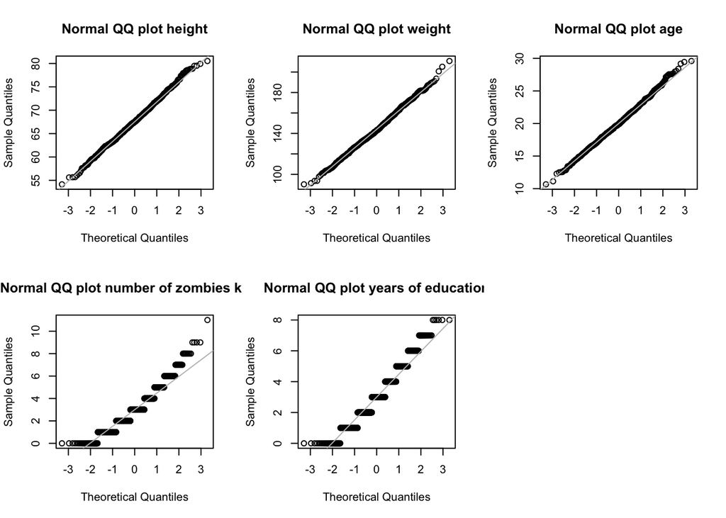

```r
# Q-Q plots using the method from Module 8

par(mfrow = c(2, 3))

qqnorm(d$height, main = "Normal QQ plot height")
qqline(d$height, col = "gray")

qqnorm(d$weight, main = "Normal QQ plot weight")
qqline(d$weight, col = "gray")

qqnorm(d$age, main = "Normal QQ plot age")
qqline(d$age, col = "gray")

qqnorm(d$zombies_killed, main = "Normal QQ plot number of zombies killed")
qqline(d$zombies_killed, col = "gray")

qqnorm(d$years_of_education, main = "Normal QQ plot years of education")
qqline(d$years_of_education, col = "gray")
```

Height, weight, and age seem to have normal distributions, though number of zombies killed and years of education do not. These may be Bernoulli or Poisson distributions.

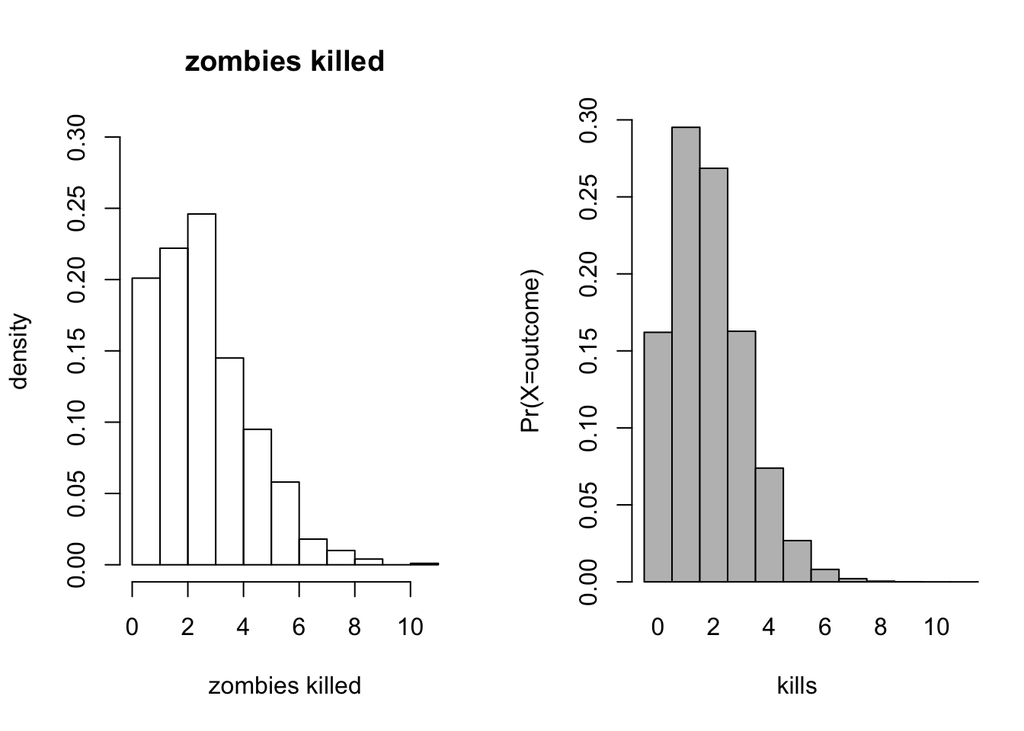

```r
par(mfrow = c(1, 2))

hist(zombies_killed, freq = FALSE, main = "zombies killed", xlab = "zombies killed",
    ylab = "density", ylim = c(0,0.3),xlim=c(0,11))

probset2<-dbinom(x=0:11,size=1000,prob=1/550)
barplot(probset2,names.arg=0:11,space=0,xlab="kills",ylab="Pr(X=outcome)",ylim=c(0,0.3),xlim=c(0,11))
```

5. Now use the sample() function to sample ONE subset of 30 zombies (without replacement) from this population and calculate the mean and sample standard deviation for each variable. Also estimate the standard error for each variable and construct the 95% confidence interval for each mean. Note that for the variables that are not drawn from the normal distribution, you will need to base your estimate of the CIs on some different distribution.

```r
# for all of the normal samples
library(sciplot)

# for height:
s_height<-sample(d$height,size=30,replace=FALSE)
mean(s_height)
```

```
## [1] 67.4873
```

```r
sd(s_height)
```

```
## [1] 3.561539
```

```r
upper_h<-mean(s_height)+qnorm(0.975,mean=0,sd=1)*se(s_height)
lower_h<-mean(s_height)+qnorm(0.025,mean=0,sd=1)*se(s_height)
ci_h<-c(lower_h,upper_h)
ci_h
```

```
## [1] 66.21284 68.76176
```

```r
# for weight:
s_weight<-sample(d$weight,size=30,replace=FALSE)
mean(s_weight)
```

```
## [1] 149.1719
```

```r
sd(s_weight)
```

```
## [1] 21.32461
```

```r
upper_w<-mean(s_weight)+qnorm(0.975,mean=0,sd=1)*se(s_weight)
lower_w<-mean(s_weight)+qnorm(0.025,mean=0,sd=1)*se(s_weight)
ci_w<-c(lower_w,upper_w)
ci_w
```

```
## [1] 141.5411 156.8027
```

```r
# for age:
s_age<-sample(d$age,size=30,replace=FALSE)
mean(s_age)
```

```
## [1] 20.51171
```

```r
sd(s_age)
```

```
## [1] 3.195431
```

```r
upper_a<-mean(s_age)+qnorm(0.975,mean=0,sd=1)*se(s_age)
lower_a<-mean(s_age)+qnorm(0.025,mean=0,sd=1)*se(s_age)
ci_a<-c(lower_a,upper_a)
ci_a
```

```
## [1] 19.36826 21.65516
```

```r
# for non-normal samples use bootstrapping

# for zombies_killed:
s_zombies_killed<-sample(d$zombies_killed,size=30,replace=FALSE)
mean(s_zombies_killed)
```

```
## [1] 3.3
```

```r
sd(s_zombies_killed)
```

```
## [1] 1.803254
```

```r
set<-NULL  # sets up a dummy variable to hold our simulations
n<-15
for (i in 1:10000) {
    set[i]<-mean(sample(s_zombies_killed,n,replace=TRUE))
}
quantile(set,c(0.025,0.975))
```

```
##  2.5% 97.5%
##   2.4   4.2
```

```r
# for years_of_education:
s_years_of_education<-sample(d$years_of_education,size=30,replace=FALSE)
mean(s_years_of_education)
```

```
## [1] 2.633333
```

```r
sd(s_years_of_education)
```

```
## [1] 1.607811
```

```r
set<-NULL
n<-15
for (i in 1:10000) {
    set[i]<-mean(sample(s_years_of_education,n,replace=TRUE))
}
quantile(set,c(0.025,0.975))
```

```
##     2.5%    97.5%
## 1.866667 3.466667
```

6. Now draw 99 more random samples of 30 zombies out and calculate the mean for each of the these samples. Together with the first sample you drew out, you now have a set of 100 means for each variable (each based on 30 observations), which constitutes a sampling distribution for each variable. What are the means and standard deviations of this distribution for each variable? How do the standard deviations compare to the standard errors estimated in [5]? What do these sampling distributions look like? Are they normally distributed? What about for those variables that you concluded were not originally drawn from a normal distribution?

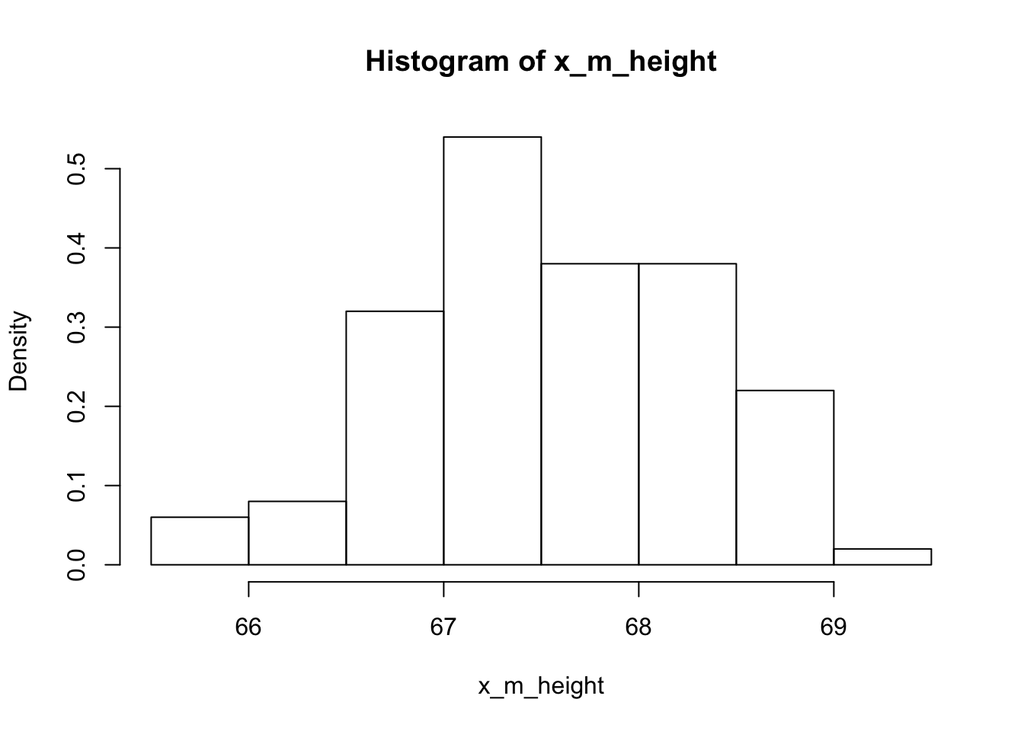

```r
x_m_height<-NULL
for (i in 1:100) {
    x_m_height[i] <- mean(sample(d$height,30))
}

hist(x_m_height,probability = TRUE)
```

```r
mean(x_m_height)
```

```
## [1] 67.5568
```

```r
sd(x_m_height)
```

```
## [1] 0.747649
```

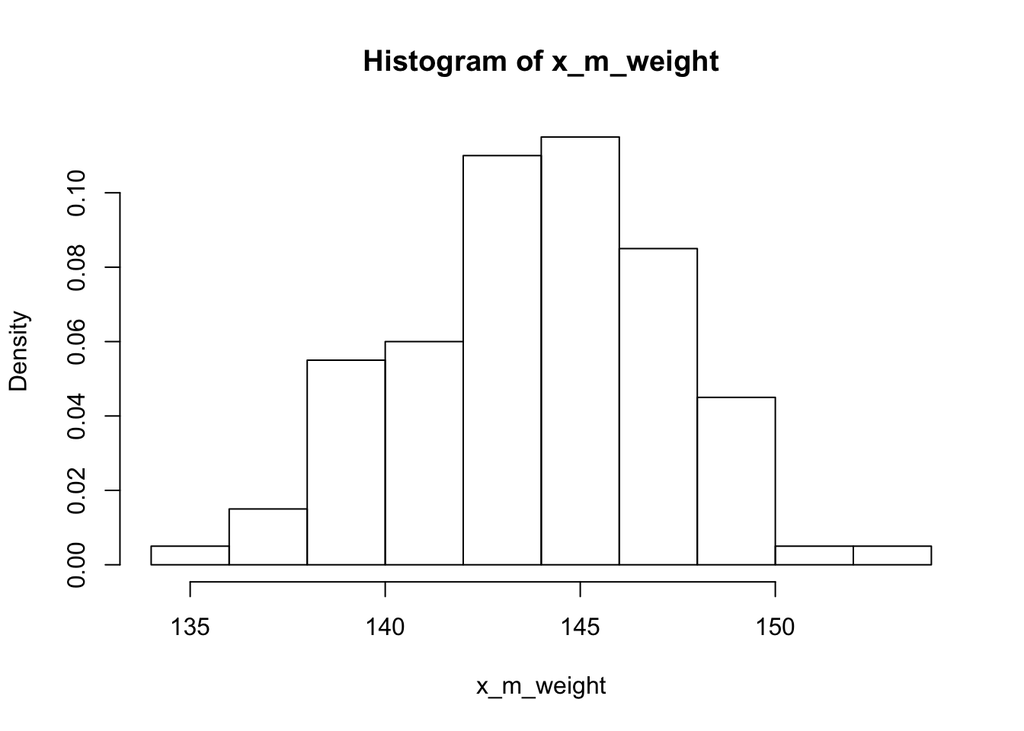

```r
x_m_weight<-NULL
for (i in 1:100) {
    x_m_weight[i] <- mean(sample(d$weight,30))
}

hist(x_m_weight,probability = TRUE)
```

```r
mean(x_m_weight)
```

```
## [1] 143.9091
```

```r
sd(x_m_weight)
```

```
## [1] 3.359214
```

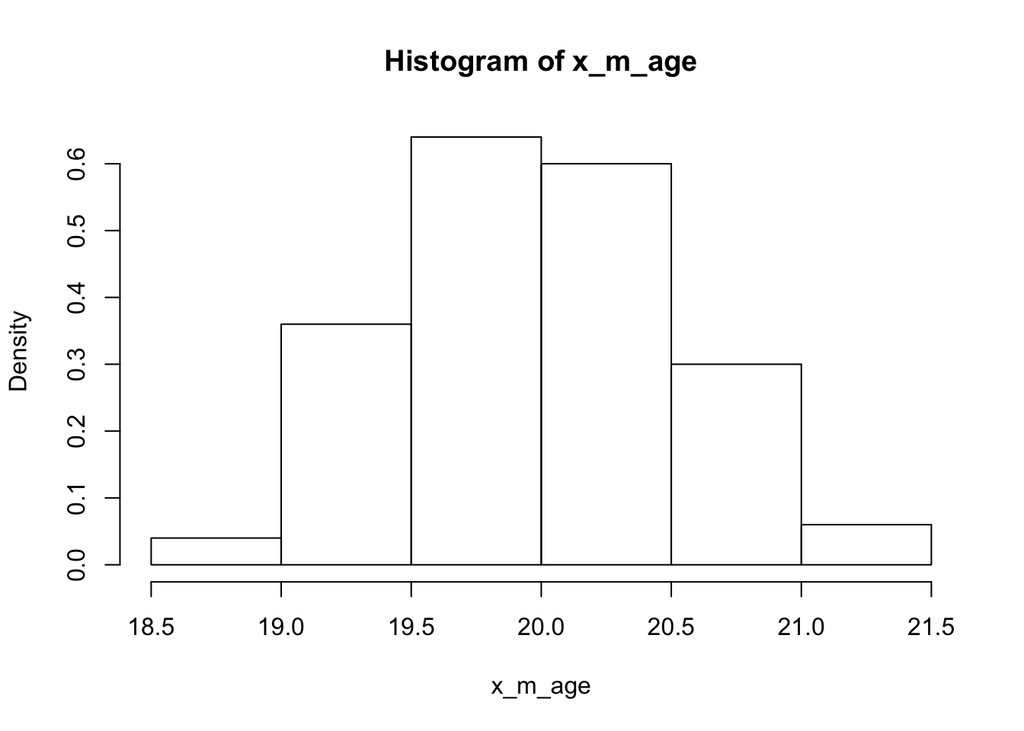

```r
x_m_age<-NULL
for (i in 1:100) {
    x_m_age[i] <- mean(sample(d$age,30))
}

hist(x_m_age,probability = TRUE)
```

```r
mean(x_m_age)
```

```
## [1] 19.97785
```

```r
sd(x_m_age)
```

```
## [1] 0.5631745
```

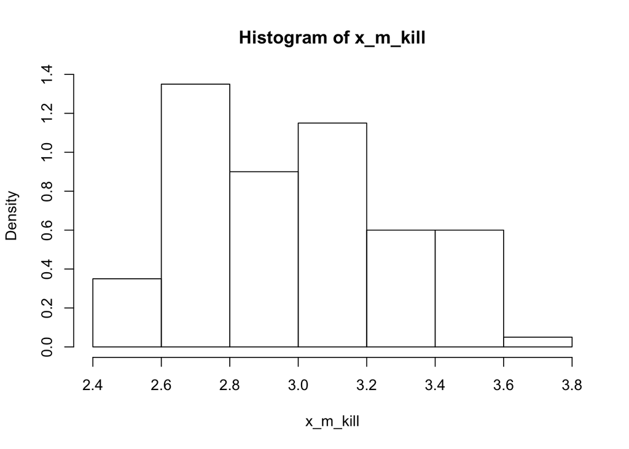

```r
x_m_kill<-NULL
for (i in 1:100) {
    x_m_kill[i] <- mean(sample(d$zombies_killed,30))
}

hist(x_m_kill,probability = TRUE)
```

```r
mean(x_m_kill)
```

```
## [1] 3.001
```

```r
sd(x_m_kill)
```

```
## [1] 0.29219
```

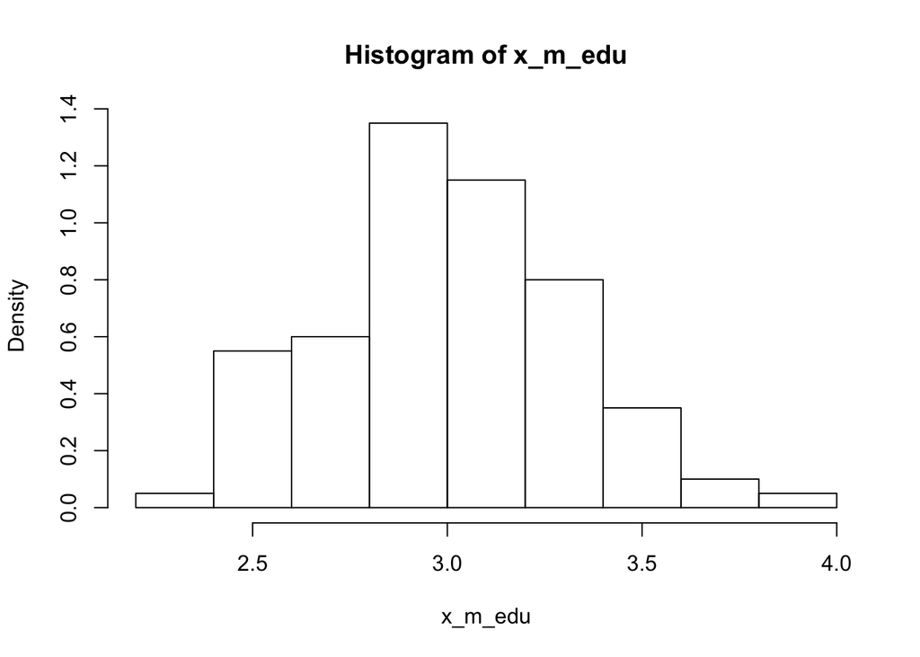

```r
x_m_edu<-NULL
for (i in 1:100) {
    x_m_edu[i] <- mean(sample(d$years_of_education,30))
}

hist(x_m_edu,probability = TRUE)
```

```r
mean(x_m_edu)
```

```
## [1] 3.024333
```

```r
sd(x_m_edu)
```

```
## [1] 0.3109254
```

The histograms all look relatively normal, even those from a non-normal distribution.